# Why should I use this model?

Dalia Camacho García Formentí Rodrigo Zepeda Tello

2018-07-05

> Hall’s model is a biomathematical model to predict changes in body weight. There are two models, one for adults (Chow and Hall 2008, Hall et al. (2011), Hall (2010), Hall and Jordan (2008)) and one for children (Hall et al. 2013, Katan et al. (2016)). In this vignette we discuss the main advantages of both models over pre-existing ones.

## Advantages of weight model

The main advantage of the model is that weight change is nonlinear and is based on the corresponding physiological processes. Therefore, it does not follow rules such as *0.45 kg for every 3500 kcals* (Hall 2008). These rules do not represent the physiological process correctly and may lead to a series of problems, such as:

### Weight change is not immediate

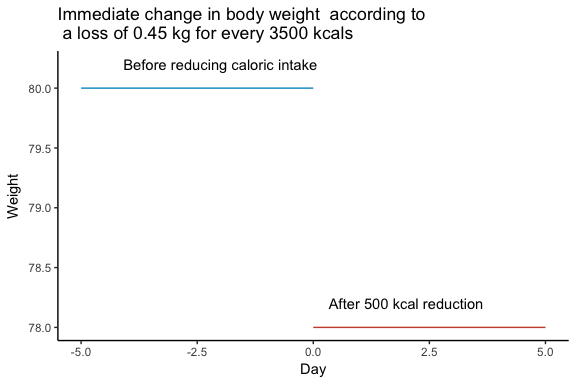

As we empirically know, weight change is not immediate; thus the blue and red lines should be connected: mass cannot simply disappear like this!

### Weight change is dependent on age, sex, and initial body mass index (BMI).

Under the same change in caloric intake, a young woman with obesity weighing $100$ kg will have a different change in body weight than an underweight grown man weighing $40$ kg. Linear rules do not consider physiological differences between individuals and thus are inaccurate for evaluating individual-level weight change:

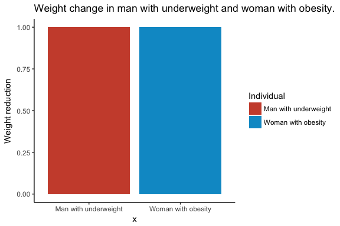

### Some linear models could lead to zero weight.

Some linear models are dependent on time. Oftentimes the previous *0.45 kg per 3500 kcals* includes a timeframe such as *0.45 kg/week per 3500 kcals* (Thomas et al. 2013). If the model is meant to predict weight in the long term some individuals might end weighing zero weight (or even negative weight!).

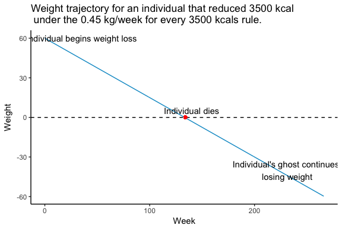

### Weight change is dependent on the previous weight change trajectory

Take for example a person was consuming 500 kcals more than those needed to maintain current weight (thus the individual is *en route* to excess weight). This individual would gain weight even if a reduction of 250 kcals on their current diet was going to take place (they would still consume 250 kcals more!). If we only consider the model given by a loss of *0.45 kg for every 3500 kcals*, this individual would lose $\frac{250 \times 0.45}{3500} = 0.032\overline{142857}$, even in the case that the caloric intake to maintain weight was exceeded by 250 kcals. This makes no sense!

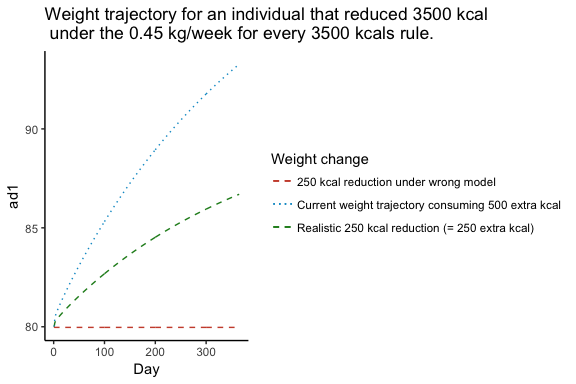

### Children naturally change weight with their growth process

During their growth process children change weight in a nonlinear way stabilizing when reaching adulthood. Any linear model such as the ALPS: $\text{Weight} = 2\cdot \big(\text{Age} + 4\big)$ (Ali, Sammy, and Nunes 2012) is bound to make incorrect predictions of future weight and end up with obese individuals every time.

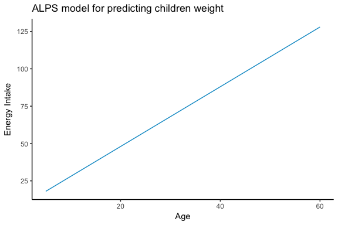

### In reality, energy intake fluctuates with time

Energy intake changes with time. This is particularly obvious in the case of children:

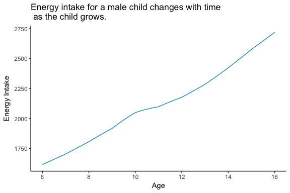

Any model needs to account for the individual’s natural energy consumption changes; in the case of children, these are associated to their growth process as explained in the previous section.

## The dynamic weight change model

The dynamic weight change model can be used to avoid problems as the ones stated before. This model considers weight change depends on physiological processes and individual characteristics such as weight, sex, age, and height. Weight change obtained from the dynamic is not immediate, and if no further changes in caloric intake take place, body weight will stabilize over time. Both the dynamic children and adult models have been previously validated (Chow and Hall 2008, Hall et al. (2011), Hall (2010), Hall and Jordan (2008), Hall et al. (2013), Katan et al. (2016)); the latter, against more than 50 different studies. Its predictive ability exceeds current models (including Comparative Risk Assesment).

An example of a weight change trajectory for an adult under the model is shown in the following graph:

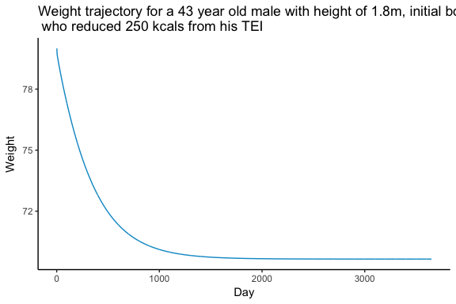

```r
trajectory <- adult_weight(80, 1.8, 43, "male", c(0, rep(-250, 3649)), days = 3650)$Body_Weight

ggplot(data.frame(Day = 1:3650, Weight = as.vector(trajectory)),
       aes(x = Day, y = Weight)) +
  geom_line(color = "deepskyblue3") +
  theme_classic() +
  ggtitle(paste("Weight trajectory for a 43 year old male with",
                "height of 1.8m, initial body weight of 80kg,\n",
                "who reduced 250 kcals from his TEI"))
```

The weight trajectory for a child also depends on their growth:

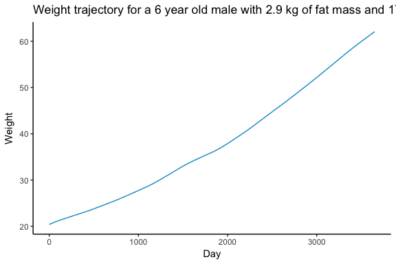

```r
trajectory <- child_weight(6,"male", FM = 2.9, FFM = 17.5, days = 3650)$Body_Weight

ggplot(data.frame(Day = 1:3650, Weight = as.vector(trajectory)),
       aes(x = Day, y = Weight)) +
  geom_line(color = "deepskyblue3") +
  theme_classic() +
  ggtitle(paste("Weight trajectory for a 6 year old male with",
                "2.9 kg of fat mass and 17.5 kg of free fat mass"))
```

For more information on the model and how to run it, you can read the package vignettes:

```r
browseVignettes("bw")
```

# References

Ali, Khalid, Ian Sammy, and Paula Nunes. 2012. “Is the Apls Formula Used to Calculate Weight-for-Age Applicable to a Trinidadian Population?” *BMC Emergency Medicine* 12 (1). BioMed Central: 9.

Chow, Carson C, and Kevin D Hall. 2008. “The Dynamics of Human Body Weight Change.” *PLoS Comput Biol* 4 (3): e1000045.

Hall, Kevin D. 2008. “What Is the Required Energy Deficit Per Unit Weight Loss?” *International Journal of Obesity* 32 (3). Nature Publishing Group: 573.

———. 2010. “Predicting Metabolic Adaptation, Body Weight Change, and Energy Intake in Humans.” *American Journal of Physiology-Endocrinology and Metabolism* 298 (3). Am Physiological Soc: E449–E466.

Hall, Kevin D, and Peter N Jordan. 2008. “Modeling Weight-Loss Maintenance to Help Prevent Body Weight Regain.” *The American Journal of Clinical Nutrition* 88 (6). Am Soc Nutrition: 1495–1503.

Hall, Kevin D, Nancy F Butte, Boyd A Swinburn, and Carson C Chow. 2013. “Dynamics of Childhood Growth and Obesity: Development and Validation of a Quantitative Mathematical Model.” *The Lancet Diabetes & Endocrinology* 1 (2). Elsevier: 97–105.

Hall, Kevin D, Gary Sacks, Dhruva Chandramohan, Carson C Chow, Y Claire Wang, Steven L Gortmaker, and Boyd A Swinburn. 2011. “Quantification of the Effect of Energy Imbalance on Bodyweight.” *The Lancet* 378 (9793). Elsevier: 826–37.

Katan, Martijn B, Janne C De Ruyter, Lothar DJ Kuijper, Carson C Chow, Kevin D Hall, and Margreet R Olthof. 2016. “Impact of Masked Replacement of Sugar-Sweetened with Sugar-Free Beverages on Body Weight Increases with Initial Bmi: Secondary Analysis of Data from an 18 Month Double–Blind Trial in Children.” *PloS One* 11 (7). Public Library of Science: e0159771.

Thomas, Diana M, Corby K Martin, Steven Lettieri, Carl Bredlau, Kathryn Kaiser, Timothy Church, Claude Bouchard, and Steven B Heymsfield. 2013. “Can a Weight Loss of One Pound a Week Be Achieved with a 3500-Kcal Deficit? Commentary on a Commonly Accepted Rule.” *International Journal of Obesity* 37 (12). Nature Publishing Group: 1611.